# eda

# plotting histogram

```r
plot_histogram =
  function(data_vector, main_title, x_label = "") {
  hist(data_vector,
       main = main_title,
       xlab = x_label,
       col = "blue")
}


png("plots/histogram_plot.png",
    width = 12 * 600,
    height = 12 * 600, res = 600)

par(mar = c(2, 2, 2, 2))
par(mfrow = c(4, 4))


column_names = names(clean_data)
for (col_name in column_names) {
  plot_histogram(clean_data[[col_name]],
                 main_title = col_name,
                 x_label = col_name)
}

dev.off()
```

# Descriptive Table with Summary Statitstics

```r
summary_stats = clean_data |>
  summarize(across(everything(),
                   list(mean = ~mean(., na.rm = TRUE),
                         median = ~median(., na.rm = TRUE),
                         sd = ~sd(., na.rm = TRUE),
                         min = ~min(., na.rm = TRUE),
                         max = ~max(., na.rm = TRUE))))

print(summary_stats)
```

```
## # A tibble: 1 × 80
##   age_mean age_median age_sd age_min age_max race_mean race_median race_sd
##      <dbl>      <dbl>  <dbl>   <dbl>   <dbl>     <dbl>       <dbl>   <dbl>
## 1     54.0         54   8.96      30      69     0.231           0   0.580
## # ℹ 72 more variables: race_min <dbl>, race_max <dbl>,
## #   marital_status_mean <dbl>, marital_status_median <dbl>,
## #   marital_status_sd <dbl>, marital_status_min <dbl>,
## #   marital_status_max <dbl>, t_stage_mean <dbl>, t_stage_median <dbl>,
## #   t_stage_sd <dbl>, t_stage_min <dbl>, t_stage_max <dbl>, n_stage_mean <dbl>,
## #   n_stage_median <dbl>, n_stage_sd <dbl>, n_stage_min <dbl>,
## #   n_stage_max <dbl>, x6th_stage_mean <dbl>, x6th_stage_median <dbl>, …
```

```r
write.csv(new_data, file = "./data/new_data.csv")
```

# Data Exploration and Visualization

## Age Distribution

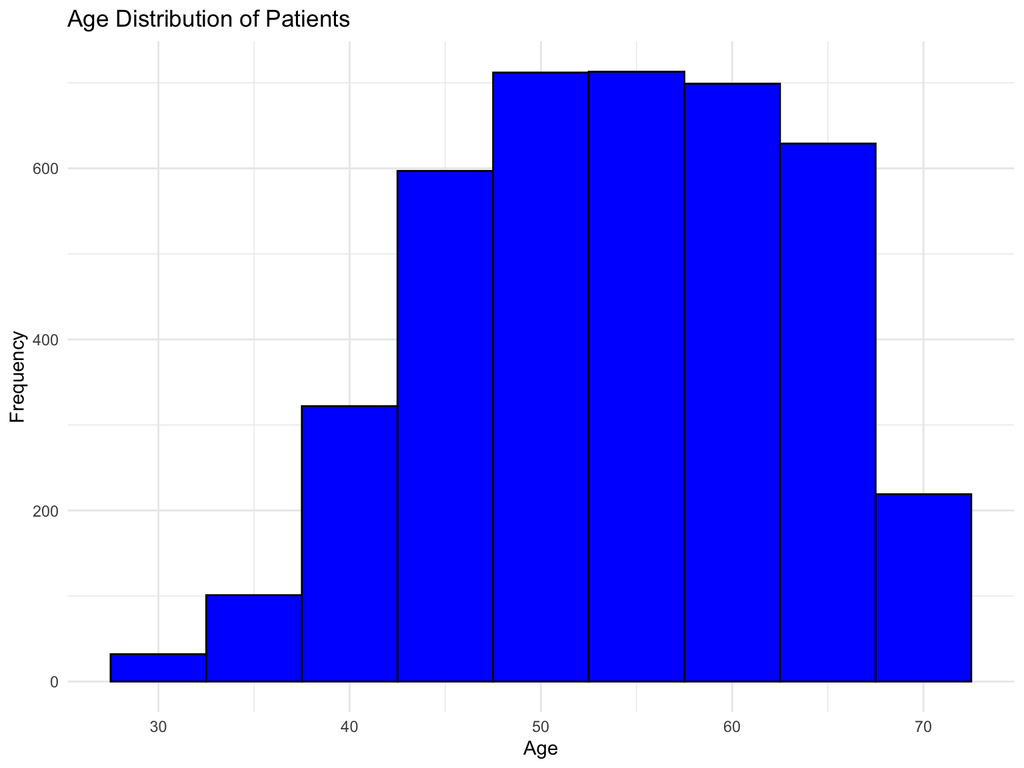

```r
# Histogram for Age Distribution
ggplot(clean_data, aes(x = age)) +
  geom_histogram(binwidth = 5, fill = "blue", color = "black") +
  ggtitle("Age Distribution of Patients") +
  xlab("Age") +
  ylab("Frequency")
```

**The histogram of the age distribution of patients shows a roughly bell-shaped curve, indicating that the ages in the dataset are normally distributed. Most patients fall within the middle age range, with fewer patients at the younger and older ends of the spectrum.**

## Race and Marital Status

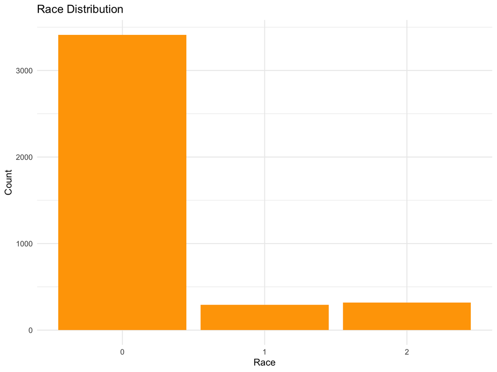

```r
# Bar Plot for Race
ggplot(clean_data, aes(x = factor(race))) +
  geom_bar(fill = "orange") +
  ggtitle("Race Distribution") +
  xlab("Race") +
  ylab("Count")
```

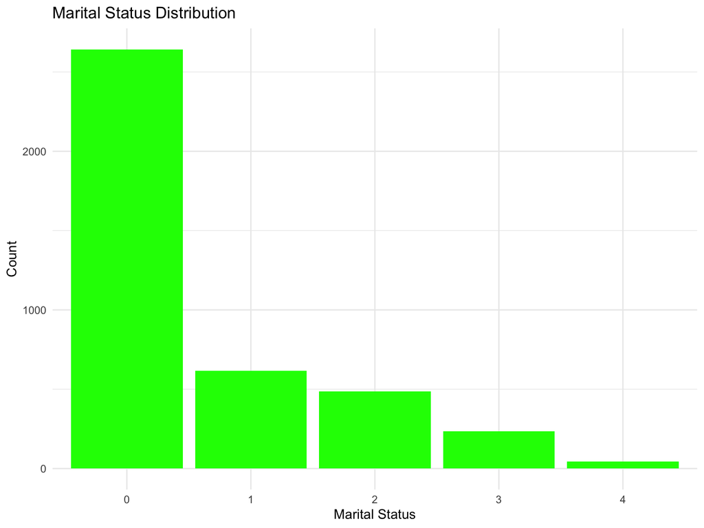

```r
# Bar Plot for Marital Status
ggplot(clean_data, aes(x = factor(marital_status))) +
  geom_bar(fill = "green") +
  ggtitle("Marital Status Distribution") +
  xlab("Marital Status") +
  ylab("Count")
```

#### Race Distribution

**The bar chart indicates a significant imbalance in the race distribution of the patient sample, with the majority of patients being of the race categorized as ‘o’ (White). Races ‘1’ (Black) and ‘2’ (other) are much less represented, suggesting that the patient data may not be as diverse in terms of racial demographics.**

### Marital Status

**The bar chart shows that the largest group of patients falls under the marital status category ‘0’, which is represent married, while the other categories, which represent single, divorced, widowed, separated, are less frequent. This suggests that the married patients are more prevalent in this particular dataset.**